# 5-Dealing+with+Categorical+Variables

## Engineer labels of categorical variables

## 1. One Hot Encoding

One hot encoding, consists of replacing the categorical variable by different boolean variables, which take value 0 or 1, to indicate whether or not a certain category / label of the variable was present for that observation.

Each one of the boolean variables are also known as **dummy variables** or binary variables.

For example, from the categorical variable "Gender", with labels 'female' and 'male', we can generate the boolean variable "female", which takes 1 if the person is female or 0 otherwise. We can also generate the variable male, which takes 1 if the person is "male" and 0 otherwise.

```python
import pandas as pd

data = pd.read_csv('titanic_feature.csv', usecols=['Sex'])
data.head()
```

|  | Sex |
| --- | --- |
| 0 | male |
| 1 | female |
| 2 | female |
| 3 | female |
| 4 | male |

```python
# one hot encoding

pd.get_dummies(data).head()
```

|  | Sex_female | Sex_male |
| --- | --- | --- |
| 0 | 0 | 1 |
| 1 | 1 | 0 |
| 2 | 1 | 0 |
| 3 | 1 | 0 |
| 4 | 0 | 1 |

```python
# for better visualisation
pd.concat([data, pd.get_dummies(data)], axis=1).head()
```

|  | Sex | Sex_female | Sex_male |
| --- | --- | --- | --- |
| 0 | male | 0 | 1 |
| 1 | female | 1 | 0 |
| 2 | female | 1 | 0 |
| 3 | female | 1 | 0 |
| 4 | male | 0 | 1 |

As you may have noticed, we only need 1 of the 2 dummy variables to represent the original categorical variable Sex. Any of the 2 will suffice, and it doesn't matter which one we select, since they are equivalent.

Therefore, to encode a categorical variable with 2 labels, we need 1 dummy variable.

To extend this concept, to encode categorical variable with k labels, we need k-1 dummy variables.

```python
# obtaining k-1 labels
pd.get_dummies(data, drop_first=True).head()
```

|  | Sex_male |
| --- | --- |
| 0 | 1 |
| 1 | 0 |
| 2 | 0 |
| 3 | 0 |
| 4 | 1 |

```python
# Let's now look at an example with more than 2 labels

data=pd.read_csv('titanic_feature.csv', usecols=['Embarked'])
data.head()
```

|  | Embarked |
| --- | --- |
| 0 | S |
| 1 | C |
| 2 | S |
| 3 | S |
| 4 | S |

```python
# check the number of different labels
data.Embarked.unique()
```

```
array(['S', 'C', 'Q', nan], dtype=object)
```

```python
# get whole set of dummy variables

pd.get_dummies(data).head()
```

|  | Embarked_C | Embarked_Q | Embarked_S |
| --- | --- | --- | --- |
| 0 | 0 | 0 | 1 |
| 1 | 1 | 0 | 0 |
| 2 | 0 | 0 | 1 |
| 3 | 0 | 0 | 1 |
| 4 | 0 | 0 | 1 |

```python
# get k-1 dummy variables

pd.get_dummies(data, drop_first=True).head()
```

|  | Embarked_Q | Embarked_S |
| --- | --- | --- |
| 0 | 0 | 1 |
| 1 | 0 | 0 |
| 2 | 0 | 1 |
| 3 | 0 | 1 |
| 4 | 0 | 1 |

```python
# we can also add an additional dummy variable to indicate whether there was missing data

pd.get_dummies(data, drop_first=True, dummy_na=True).head()
```

|  | Embarked_Q | Embarked_S | Embarked_nan |
| --- | --- | --- | --- |
| 0 | 0 | 1 | 0 |
| 1 | 0 | 0 | 0 |
| 2 | 0 | 1 | 0 |
| 3 | 0 | 1 | 0 |
| 4 | 0 | 1 | 0 |

```python
# by summing the number of 1s per boolean variable over the rows of the dataset, we get to know how
# many observations we have for each variable (i.e., each category)

pd.get_dummies(data, drop_first=True, dummy_na=True).sum(axis=0)
```

```
Embarked_Q       77
Embarked_S      644
Embarked_nan      2
dtype: int64
```

### Notes

Both pandas and sklearn will provide a whole set of dummy variables from a categorical variable. This is, instead of returning k-1 binary variables, they will return k, with the option in pandas of dropping the first binary variable and obtain k-1.

### When should you use k and when k-1?

When the original variable is binary, that is, when the original variable has only 2 labels, then you should create **one and only one** binary variable.

When the original variable has more than 2 labels, the following is important:

#### One hot encoding into k-1: (With Binary Variables and Use in Linear Regression)

One hot encoding into k-1 binary variables takes into account that we can use 1 less dimension and still represent the whole information: if the observation is 0 in all the binary variables, then it must be 1 in the final (removed) binary variable. As an example, for the variable gender encoded into male, if the observation is 0, then it has to be female. We do not need the additional female variable to explain that.

One hot encoding with k-1 binary variables should be used in linear regression, to keep the correct number of degrees of freedom (k-1). The linear regression has access to all of the features as it is being trained, and therefore examines altogether the whole set of dummy variables. This means that k-1 binary variables give the whole information about (represent completely) the original categorical variable to the linear regression.

And the same is true for all machine learning algorithms that look at ALL the features at the same time during training. For example, support vector machines and neural networks as well. And clustering algorithms.

#### One hot encoding into k dummy variables (Used in Trees and Feature Selection)

However, tree based models select at each iteration only a group of features to make a decision. This is to separate the data at each node. Therefore, the last category, the one that was removed in the one hot encoding into k-1 variables, would only be taken into account by those splits or even trees, that use the entire set of binary variables at a time. And this would rarely happen, because each split usually uses 1-3 features to make a decision. So, tree based methods will never consider that additional label, the one that was dropped. Thus, if the categorical variables will be used in a tree based learning algorithm, it is good practice to encode it into k binary variables instead of k-1.

Finally, if you are planning to do feature selection, you will also need the entire set of binary variables (k) to let the machine learning model select which ones have the most predictive power.

Let's train a model on data with categorical variables re-encoded with One Hot Encoding.

```python
import pandas as pd
import numpy as np

from sklearn.linear_model import LogisticRegression
from sklearn.ensemble import AdaBoostClassifier
from sklearn.ensemble import RandomForestClassifier

from sklearn.metrics import roc_auc_score
from sklearn.model_selection import train_test_split
```

```python
data = pd.read_csv('titanic_feature.csv')
data.head()
```

|  | PassengerId | Survived | Pclass | Name | Sex | Age | SibSp | Parch | Ticket | Fare | Cabin | Embarked |
| --- | --- | --- | --- | --- | --- | --- | --- | --- | --- | --- | --- | --- |
| 0 | 1 | 0 | 3 | Braund, Mr. Owen Harris | male | 22.0 | 1 | 0 | A/5 21171 | 7.2500 | NaN | S |
| 1 | 2 | 1 | 1 | Cumings, Mrs. John Bradley (Florence Briggs Th... | female | 38.0 | 1 | 0 | PC 17599 | 71.2833 | C85 | C |
| 2 | 3 | 1 | 3 | Heikkinen, Miss. Laina | female | 26.0 | 0 | 0 | STON/O2. 3101282 | 7.9250 | NaN | S |
| 3 | 4 | 1 | 1 | Futrelle, Mrs. Jacques Heath (Lily May Peel) | female | 35.0 | 1 | 0 | 113803 | 53.1000 | C123 | S |
| 4 | 5 | 0 | 3 | Allen, Mr. William Henry | male | 35.0 | 0 | 0 | 373450 | 8.0500 | NaN | S |

```python
# let's make a copy of the dataset, in which we encode the categorical variables using One Hot Encoding (OHE)

data_OHE = pd.concat([data[['Pclass', 'Age', 'SibSp','Parch', 'Survived']], # numerical variables
                      pd.get_dummies(data.Sex, drop_first=True),   # binary categorical variable
                      pd.get_dummies(data.Embarked, drop_first=True)],  # k categories in categorical
                    axis=1)

data_OHE.head()
```

|  | Pclass | Age | SibSp | Parch | Survived | male | Q | S |
| --- | --- | --- | --- | --- | --- | --- | --- | --- |
| 0 | 3 | 22.0 | 1 | 0 | 0 | 1 | 0 | 1 |
| 1 | 1 | 38.0 | 1 | 0 | 1 | 0 | 0 | 0 |
| 2 | 3 | 26.0 | 0 | 0 | 1 | 0 | 0 | 1 |
| 3 | 1 | 35.0 | 1 | 0 | 1 | 0 | 0 | 1 |
| 4 | 3 | 35.0 | 0 | 0 | 0 | 1 | 0 | 1 |

```python
# and now let's separate into train and test set

X_train, X_test, y_train, y_test = train_test_split(data_OHE[['Pclass', 'Age', 'SibSp',
                                                              'Parch', 'male', 'Q', 'S']].fillna(0),
                                                    data_OHE.Survived,
                                                    test_size=0.3,
                                                    random_state=0)
X_train.shape, X_test.shape
```

```
((623, 7), (268, 7))
```

```python
# let's build a random forest

rf = RandomForestClassifier(n_estimators=200, random_state=39, max_depth=3)
rf.fit(X_train, y_train)
print('Train set')
pred = rf.predict_proba(X_train)
print('Random Forests roc-auc: {}'.format(roc_auc_score(y_train, pred[:,1])))
print('Test set')
pred = rf.predict_proba(X_test)
print('Random Forests roc-auc: {}'.format(roc_auc_score(y_test, pred[:,1])))
```

```
Train set
Random Forests roc-auc: 0.8696177957094205
Test set
Random Forests roc-auc: 0.8606250000000001
```

## One Hot encoding: final notes

### Advantages

- Straightforward to implement
- Makes no assumption
- Keeps all the information of the categorical variable

### Disadvantages

- Does not add any information that may make the variable more predictive
- If the variable has loads of categories, then OHE increases the feature space dramatically

```python
# let's load the variable Cabin of the titanic dataset

data = pd.read_csv('titanic_feature.csv', usecols = ['Cabin'])
data.head()
```

|  | Cabin |
| --- | --- |
| 0 | NaN |
| 1 | C85 |
| 2 | NaN |
| 3 | C123 |
| 4 | NaN |

```python
# let's inspect the number of different labels in Cabin

print('number of labels: {}'.format(len(data.Cabin.unique())))
```

```
number of labels: 148
```

```python
# let's see how many features we would create if we did OHE for Cabin

Cabin_OHE = pd.get_dummies(data.Cabin)
Cabin_OHE.shape
```

```
(891, 147)
```

```python
Cabin_OHE.head()
```

|  | A10 | A14 | A16 | A19 | A20 | A23 | A24 | A26 | A31 | A32 | ... | E8 | F E69 | F G63 | F G73 | F2 | F33 | F38 | F4 | G6 | T |
| --- | --- | --- | --- | --- | --- | --- | --- | --- | --- | --- | --- | --- | --- | --- | --- | --- | --- | --- | --- | --- | --- |
| 0 | 0 | 0 | 0 | 0 | 0 | 0 | 0 | 0 | 0 | 0 | ... | 0 | 0 | 0 | 0 | 0 | 0 | 0 | 0 | 0 | 0 |
| 1 | 0 | 0 | 0 | 0 | 0 | 0 | 0 | 0 | 0 | 0 | ... | 0 | 0 | 0 | 0 | 0 | 0 | 0 | 0 | 0 | 0 |
| 2 | 0 | 0 | 0 | 0 | 0 | 0 | 0 | 0 | 0 | 0 | ... | 0 | 0 | 0 | 0 | 0 | 0 | 0 | 0 | 0 | 0 |
| 3 | 0 | 0 | 0 | 0 | 0 | 0 | 0 | 0 | 0 | 0 | ... | 0 | 0 | 0 | 0 | 0 | 0 | 0 | 0 | 0 | 0 |
| 4 | 0 | 0 | 0 | 0 | 0 | 0 | 0 | 0 | 0 | 0 | ... | 0 | 0 | 0 | 0 | 0 | 0 | 0 | 0 | 0 | 0 |

5 rows × 147 columns

If we performed OHE in the variable Cabin that contains 148 different labels, we would end up with 147 variables, where originally there was one. If we have a few categorical variables like this, we would end up with huge datasets. Therefore, OHE is not always the best option to encode categorical variables.

### Notes

If our datasets have a few multi-label variables, we will end up very soon with datasets with thousands of columns or more. And this may make training of our algorithms slow. In addition, many of these dummy variables may be similar to each other, since it is not unusual for 2 or more variables to share the same combinations of 1 and 0s.

# 2: Hot Encode Top 10 Labels

```python
# let's make a list with the most frequent categories of the variable
top_10 = [x for x in data.Cabin.value_counts().sort_values(ascending=False).head(10).index]
top_10
```

```
['C23 C25 C27',
 'G6',
 'B96 B98',
 'C22 C26',
 'F33',
 'E101',
 'F2',
 'D',
 'C83',
 'D26']
```

```python
# get whole set of dummy variables, for all the categorical variables

def one_hot_top_x(df, variable, top_x_labels):
    # function to create the dummy variables for the most frequent labels
    # we can vary the number of most frequent labels that we encode

    for label in top_x_labels:
        df[variable+'_'+label] = np.where(data[variable]==label, 1, 0)
```

```python
one_hot_top_x(data, 'Cabin', top_10)
data.head()
```

|  | Cabin | Cabin_C23 C25 C27 | Cabin_G6 | Cabin_B96 B98 | Cabin_C22 C26 | Cabin_F33 | Cabin_E101 | Cabin_F2 | Cabin_D | Cabin_C83 | Cabin_D26 |
| --- | --- | --- | --- | --- | --- | --- | --- | --- | --- | --- | --- |
| 0 | NaN | 0 | 0 | 0 | 0 | 0 | 0 | 0 | 0 | 0 | 0 |
| 1 | C85 | 0 | 0 | 0 | 0 | 0 | 0 | 0 | 0 | 0 | 0 |
| 2 | NaN | 0 | 0 | 0 | 0 | 0 | 0 | 0 | 0 | 0 | 0 |
| 3 | C123 | 0 | 0 | 0 | 0 | 0 | 0 | 0 | 0 | 0 | 0 |
| 4 | NaN | 0 | 0 | 0 | 0 | 0 | 0 | 0 | 0 | 0 | 0 |

### One Hot encoding of top variables

### Advantages

- Straightforward to implement
- Does not require hrs of variable exploration
- Does not expand massively the feature space (number of columns in the dataset)

### Disadvantages

- Does not add any information that may make the variable more predictive
- Does not keep the information of the ignored labels (To avoid it, club other labels into a single category the way we treated the Rare values)

# 3: Ordinal Number Encoding

## Ordinal numbering encoding

**Ordinal categorical variables**

Categorical variable which categories can be meaningfully ordered are called ordinal. For example:

- Student's grade in an exam (A, B, C or Fail).
- Days of the week can be ordinal with Monday = 1, and Sunday = 7.
- Educational level, with the categories: Elementary school, High school, College graduate, PhD ranked from 1 to 4.

When the categorical variable is ordinal, the most straightforward approach is to replace the labels by some ordinal number.

### Advantages

- Keeps the semantical information of the variable (human readable content)
- Straightforward

### Disadvantage

- Does not add machine learning valuable information

```python
import datetime
base = datetime.datetime.today()
date_list = [base - datetime.timedelta(days=x) for x in range(0, 30)]
df = pd.DataFrame(date_list)
df.columns = ['day']
df
```

|  | day |
| --- | --- |
| 0 | 2019-08-31 17:29:52.854383 |
| 1 | 2019-08-30 17:29:52.854383 |
| 2 | 2019-08-29 17:29:52.854383 |
| 3 | 2019-08-28 17:29:52.854383 |
| 4 | 2019-08-27 17:29:52.854383 |
| 5 | 2019-08-26 17:29:52.854383 |
| 6 | 2019-08-25 17:29:52.854383 |
| 7 | 2019-08-24 17:29:52.854383 |
| 8 | 2019-08-23 17:29:52.854383 |
| 9 | 2019-08-22 17:29:52.854383 |
| 10 | 2019-08-21 17:29:52.854383 |
| 11 | 2019-08-20 17:29:52.854383 |
| 12 | 2019-08-19 17:29:52.854383 |
| 13 | 2019-08-18 17:29:52.854383 |
| 14 | 2019-08-17 17:29:52.854383 |
| 15 | 2019-08-16 17:29:52.854383 |
| 16 | 2019-08-15 17:29:52.854383 |
| 17 | 2019-08-14 17:29:52.854383 |
| 18 | 2019-08-13 17:29:52.854383 |
| 19 | 2019-08-12 17:29:52.854383 |
| 20 | 2019-08-11 17:29:52.854383 |
| 21 | 2019-08-10 17:29:52.854383 |
| 22 | 2019-08-09 17:29:52.854383 |
| 23 | 2019-08-08 17:29:52.854383 |
| 24 | 2019-08-07 17:29:52.854383 |
| 25 | 2019-08-06 17:29:52.854383 |
| 26 | 2019-08-05 17:29:52.854383 |
| 27 | 2019-08-04 17:29:52.854383 |
| 28 | 2019-08-03 17:29:52.854383 |
| 29 | 2019-08-02 17:29:52.854383 |

```python
# extract the week day name

df['day_of_week'] = df['day'].dt.weekday_name
df.head()
```

|  | day | day_of_week |
| --- | --- | --- |
| 0 | 2019-08-31 17:29:52.854383 | Saturday |
| 1 | 2019-08-30 17:29:52.854383 | Friday |
| 2 | 2019-08-29 17:29:52.854383 | Thursday |
| 3 | 2019-08-28 17:29:52.854383 | Wednesday |
| 4 | 2019-08-27 17:29:52.854383 | Tuesday |

```python
# Engineer categorical variable by ordinal number replacement

weekday_map = {'Monday':1,
               'Tuesday':2,
               'Wednesday':3,
               'Thursday':4,
               'Friday':5,
               'Saturday':6,
               'Sunday':7
}

df['day_ordinal'] = df.day_of_week.map(weekday_map)
df.head(10)
```

|  | day | day_of_week | day_ordinal |
| --- | --- | --- | --- |
| 0 | 2019-08-31 17:29:52.854383 | Saturday | 6 |
| 1 | 2019-08-30 17:29:52.854383 | Friday | 5 |
| 2 | 2019-08-29 17:29:52.854383 | Thursday | 4 |
| 3 | 2019-08-28 17:29:52.854383 | Wednesday | 3 |
| 4 | 2019-08-27 17:29:52.854383 | Tuesday | 2 |
| 5 | 2019-08-26 17:29:52.854383 | Monday | 1 |
| 6 | 2019-08-25 17:29:52.854383 | Sunday | 7 |
| 7 | 2019-08-24 17:29:52.854383 | Saturday | 6 |
| 8 | 2019-08-23 17:29:52.854383 | Friday | 5 |
| 9 | 2019-08-22 17:29:52.854383 | Thursday | 4 |

# 4. Count or Frequency Encoding

## Count or frequency encoding

Another way to refer to variables that have a multitude of categories, is to call them variables with **high cardinality**.

We observed in the previous lecture, that if a categorical variable contains multiple labels, then by re-encoding them using one hot encoding, we will expand the feature space dramatically.

One approach that is heavily used in Kaggle competitions, is to replace each label of the categorical variable by the count, this is the amount of times each label appears in the dataset. Or the frequency, this is the percentage of observations within that category. The 2 are equivalent.

There is not any rationale behind this transformation, other than its simplicity.

### Advantages

- Simple
- Does not expand the feature space

### Disadvantages

- If 2 labels appear the same amount of times in the dataset, that is, contain the same number of observations, they will be merged: may loose valuable information
- Adds somewhat arbitrary numbers, and therefore weights to the different labels, that may not be related to their predictive power

Follow this thread in Kaggle for more information: https://www.kaggle.com/general/16927

```python
import pandas as pd
import numpy as np

from sklearn.model_selection import train_test_split

# let's open the mercedes benz dataset for demonstration

data = pd.read_csv('mercedes_benz_train.csv', usecols=['X1', 'X2', 'X3', 'X4', 'X5', 'X6', 'y'])
data.head()
```

|  | y | X1 | X2 | X3 | X4 | X5 | X6 |
| --- | --- | --- | --- | --- | --- | --- | --- |
| 0 | 130.81 | v | at | a | d | u | j |
| 1 | 88.53 | t | av | e | d | y | l |
| 2 | 76.26 | w | n | c | d | x | j |
| 3 | 80.62 | t | n | f | d | x | l |
| 4 | 78.02 | v | n | f | d | h | d |

```python
# let's have a look at how many unique labels each column has got

for col in data.columns[1:]:
    print(col, ': ', len(data[col].unique()), ' labels')
```

```
X1 :  27  labels
X2 :  44  labels
X3 :  7  labels
X4 :  4  labels
X5 :  29  labels
X6 :  12  labels
```

```python
X_train, X_test, y_train, y_test = train_test_split(data[['X1', 'X2', 'X3', 'X4', 'X5', 'X6']], data.y,
                                                    test_size=0.3,
                                                    random_state=0)
X_train.shape, X_test.shape
```

```
((2946, 6), (1263, 6))
```

```python
# let's obtain the counts for each one of the labels in variable X2
# let's capture this in a dictionary that we can use to re-map the labels

X_train.X2.value_counts().to_dict()
```

```
{'a': 34,
 'aa': 1,
 'ac': 10,
 'ae': 342,
 'af': 1,
 'ag': 15,
 'ah': 3,
 'ai': 289,
 'ak': 188,
 'al': 3,
 'am': 1,
 'an': 3,
 'ao': 10,
 'ap': 5,
 'aq': 46,
 'as': 1155,
 'at': 5,
 'au': 3,
 'av': 2,
 'aw': 2,
 'ay': 40,
 'b': 12,
 'c': 1,
 'd': 12,
 'e': 61,
 'f': 59,
 'g': 10,
 'h': 4,
 'i': 15,
 'k': 16,
 'l': 1,
 'm': 284,
 'n': 97,
 'o': 1,
 'p': 1,
 'q': 3,
 'r': 101,
 's': 63,
 't': 17,
 'x': 8,
 'y': 8,
 'z': 14}
```

```python
# And now let's replace each label in X2 by its count

# first we make a dictionary that maps each label to the counts
X_frequency_map = X_train.X2.value_counts().to_dict()
print(X_frequency_map)
```

```
{'as': 1155, 'ae': 342, 'ai': 289, 'm': 284, 'ak': 188, 'r': 101, 'n': 97, 's': 63, 'e': 61, 'f': 59, 'aq': 46, 'ay': 40, 'a': 34, 't': 17, 'k': 16, 'i': 15, 'ag': 15, 'z': 14, 'b': 12, 'd': 12, 'ac': 10, 'ao': 10, 'g': 10, 'y': 8, 'x': 8, 'at': 5, 'ap': 5, 'h': 4, 'ah': 3, 'au': 3, 'al': 3, 'an': 3…
```

```python
X_train.head()
```

|  | X1 | X2 | X3 | X4 | X5 | X6 |
| --- | --- | --- | --- | --- | --- | --- |
| 3059 | aa | ai | c | d | q | g |
| 3014 | b | m | c | d | q | i |
| 3368 | o | f | f | d | s | l |
| 2772 | aa | as | d | d | p | j |
| 3383 | v | e | c | d | s | g |

```python
# and now we replace X2 labels both in train and test set with the same map
X_train.X2 = X_train.X2.map(X_frequency_map)
X_test.X2 = X_test.X2.map(X_frequency_map)

X_train.head()
```

|  | X1 | X2 | X3 | X4 | X5 | X6 |
| --- | --- | --- | --- | --- | --- | --- |
| 3059 | aa | 289 | c | d | q | g |
| 3014 | b | 284 | c | d | q | i |
| 3368 | o | 59 | f | d | s | l |
| 2772 | aa | 1155 | d | d | p | j |
| 3383 | v | 61 | c | d | s | g |

Where in the original dataset, for the observation 1 in the variable 2 before it was 'ai', now it was replaced by the count 289. And so on for the rest of the categories (compare outputs 5 and 6).

### Note

If a category is present in the test set, that was not present in the train set, this method will generate missing data in the test set. Then we can combine rare label replacement plus categorical encoding with counts like this: we may choose to replace the 10 most frequent labels by their count, and then group all the other labels under one label (for example "Rare"), and replace "Rare" by its count, to account for what I just mentioned.

There is no rule of thumb to indicate which method you should use to encode categorical variables. It is mostly up to what makes sense for the data, and it also depends on what you are trying to achieve. In general, for data competitions, we value more model predictive power, whereas in business scenarios we want to capture and understand the information, and generally, we want to transform variables in a way that it makes 'Business sense'. Some of your common sense and a lot of conversation with the people that understand the data well will be required to encode categorical labels.

# 5.Monotonicity

A monotonic relationship is a relationship that does one of the following:

(1) As the value of one variable increases, so does the value of the other variable; or

(2) As the value of one variable increases, the other variable value decreases.

In this case, as the value of the independent variable (predictor) increases, so does the target, or conversely, as the value of the variable increases, the target decreases.

In general:

## Advantages:

Capture information within the label, therefore rendering more predictive features Create a monotonic relationship between the variable and the target

Do not expand the feature space

## Disadvantage

Prone to cause over-fitting

```python
# let's load again the titanic dataset

data = pd.read_csv('titanic_feature.csv', usecols=['Cabin', 'Survived'])
data.head()
```

|  | Survived | Cabin |
| --- | --- | --- |
| 0 | 0 | NaN |
| 1 | 1 | C85 |
| 2 | 1 | NaN |
| 3 | 1 | C123 |
| 4 | 0 | NaN |

```python
# let's first fill NA values with an additional label

data.Cabin.fillna('Missing', inplace=True)
data.head()
```

|  | Survived | Cabin |
| --- | --- | --- |
| 0 | 0 | Missing |
| 1 | 1 | C85 |
| 2 | 1 | Missing |
| 3 | 1 | C123 |
| 4 | 0 | Missing |

```python
# Cabin has indeed a lot of labels, here for simplicity, I will capture the first letter of the cabin,
# but the procedure could be done as well without any prior variable manipulation

len(data.Cabin.unique()) # check number of different labels in Cabin
```

```
148
```

```python
# Now we extract the first letter of the cabin

data['Cabin'] = data['Cabin'].astype(str).str[0]
data.head()
```

|  | Survived | Cabin |
| --- | --- | --- |
| 0 | 0 | M |
| 1 | 1 | C |
| 2 | 1 | M |
| 3 | 1 | C |
| 4 | 0 | M |

```python
# check the labels again, we have much less categories in Cabin now

data.Cabin.unique()
```

```
array(['M', 'C', 'E', 'G', 'D', 'A', 'B', 'F', 'T'], dtype=object)
```

```python
# Let's separate into train and test set

X_train, X_test, y_train, y_test = train_test_split(
    data[['Cabin', 'Survived']], data.Survived, test_size=0.3, random_state=0)

X_train.shape, X_test.shape
```

```
((623, 2), (268, 2))
```

```python
# now we order the labels according to the mean of the target value (in this case, mean of 0 and 1):
## less than 0.5 indicates 0
## more than 0.5 indicates 1

X_train.groupby(['Cabin'])['Survived'].mean().sort_values()
```

```
Cabin
T    0.000000
M    0.303609
A    0.428571
G    0.500000
C    0.571429
F    0.666667
D    0.692308
E    0.740741
B    0.774194
Name: Survived, dtype: float64
```

```python
# now we generate an ordered list with the labels
X_train.groupby(['Cabin'])['Survived'].mean().sort_values().index
```

```
Index(['T', 'M', 'A', 'G', 'C', 'F', 'D', 'E', 'B'], dtype='object', name='Cabin')
```

```python
# now we generate an ordered list with the labels (same as above but we capture the list in a variable)

ordered_labels = X_train.groupby(['Cabin'])['Survived'].mean().sort_values().index
print(ordered_labels)
```

```
Index(['T', 'M', 'A', 'G', 'C', 'F', 'D', 'E', 'B'], dtype='object', name='Cabin')
```

```python
# and now we create a dictionary that maps each label to the number starting with 0

ordinal_label = {k:i for i, k in enumerate(ordered_labels, 1)}
ordinal_label
```

```
{'A': 3, 'B': 9, 'C': 5, 'D': 7, 'E': 8, 'F': 6, 'G': 4, 'M': 2, 'T': 1}
```

```python
# replace the labels with the ordered numbers
# both in train and test set (note that we created the dictionary only using the training set)

X_train['Cabin_ordered'] = X_train.Cabin.map(ordinal_label)
X_test['Cabin_ordered'] = X_test.Cabin.map(ordinal_label)
```

```python
# check the results

X_train.head()
```

|  | Cabin | Survived | Cabin_ordered |
| --- | --- | --- | --- |
| 857 | E | 1 | 8 |
| 52 | D | 1 | 7 |
| 386 | M | 0 | 2 |
| 124 | D | 0 | 7 |
| 578 | M | 0 | 2 |

```python
# let's inspect the newly created monotonic relationship with the target

#first we plot the original variable for comparison, there is no monotonic relationship
import matplotlib.pyplot as plt
%matplotlib inline

fig = plt.figure()
fig = X_train.groupby(['Cabin'])['Survived'].mean().plot()
fig.set_title('Normal relationship between variable and target')
fig.set_ylabel('Survived')
```

```
Text(0,0.5,'Survived')
```

```
Text(0,0.5,'Survived')
```

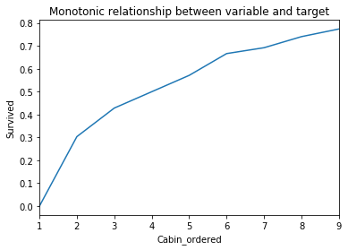

```python
# plot the transformed result: the monotonic variable

fig = plt.figure()
fig = X_train.groupby(['Cabin_ordered'])['Survived'].mean().plot()
fig.set_title('Monotonic relationship between variable and target')
fig.set_ylabel('Survived')
```

There is now a monotonic relationship between the variable Cabin and probability of survival. The higher the Cabin number, the more likely the person was to survive.

### Note

Monotonic does not mean strictly linear. Monotonic means that it increases constantly, or it decreases constantly.

Replacing categorical labels with this code and method will generate missing values for categories present in the test set that were not seen in the training set. Therefore it is extremely important to handle rare labels before-hand.

# 6. Replace labels by the Risk Factor

Replacing labels by the risk factor means essentially replacing the label by the mean of the target for that label.

This procedure is mostly seen applied in classifications scenarios, where the target can take just the values of 1 or 0. However, in principle, there is no reason why this shouldn't be possible as well when the target is continuous. Just be mindful of over-fitting.

```python
# let's load again the titanic dataset

data = pd.read_csv('titanic_feature.csv', usecols=['Cabin', 'Survived'])
print(data.head())
print("\n")

# let's first fill NA values with an additional label

data.Cabin.fillna('Missing', inplace=True)
print(data.head())
print("\n")

print(len(data.Cabin.unique())) # check number of different labels in Cabin

# Now we extract the first letter of the cabin
print("\n")
data['Cabin'] = data['Cabin'].astype(str).str[0]
print(data.head())
print("\n")
# check the labels
print(data.Cabin.unique())
```

```
   Survived Cabin
0         0   NaN
1         1   C85
2         1   NaN
3         1  C123
4         0   NaN


   Survived    Cabin
0         0  Missing
1         1      C85
2         1  Missing
3         1     C123
4         0  Missing


148


   Survived Cabin
0         0     M
1         1     C
2         1     M
3         1     C
4         0     M


['M' 'C' 'E' 'G' 'D' 'A' 'B' 'F' 'T']
```

```python
# Let's separate into training and testing set

X_train, X_test, y_train, y_test = train_test_split(data[['Cabin', 'Survived']], data.Survived, test_size=0.3,
                                                    random_state=0)
X_train.shape, X_test.shape
```

```
((623, 2), (268, 2))
```

```python
# now we order the labels according to the mean of the target value (in this case, mean of 0 and 1)
X_train.groupby(['Cabin'])['Survived'].mean().sort_values()
```

```
Cabin
T    0.000000
M    0.303609
A    0.428571
G    0.500000
C    0.571429
F    0.666667
D    0.692308
E    0.740741
B    0.774194
Name: Survived, dtype: float64
```

```python
# and now let's do the same but capturing the result in a dictionary

ordered_labels = X_train.groupby(['Cabin'])['Survived'].mean().to_dict()
ordered_labels
```

```
{'A': 0.42857142857142855,
 'B': 0.7741935483870968,
 'C': 0.5714285714285714,
 'D': 0.6923076923076923,
 'E': 0.7407407407407407,
 'F': 0.6666666666666666,
 'G': 0.5,
 'M': 0.3036093418259023,
 'T': 0.0}
```

```python
# replace the labels with the 'risk' (target frequency)
# note that we calculated the frequencies based on the training set only

X_train['Cabin_ordered'] = X_train.Cabin.map(ordered_labels)
X_test['Cabin_ordered'] = X_test.Cabin.map(ordered_labels)
```

```python
# check the results

X_train.head()
```

|  | Cabin | Survived | Cabin_ordered |
| --- | --- | --- | --- |
| 857 | E | 1 | 0.740741 |
| 52 | D | 1 | 0.692308 |
| 386 | M | 0 | 0.303609 |
| 124 | D | 0 | 0.692308 |
| 578 | M | 0 | 0.303609 |

```python
# plot the original variable

fig = plt.figure()
fig = X_train.groupby(['Cabin'])['Survived'].mean().plot()
fig.set_title('Normal relationship between variable and target')
fig.set_ylabel('Survived')
```

```
Text(0,0.5,'Survived')
```

```
Text(0,0.5,'Survived')
```

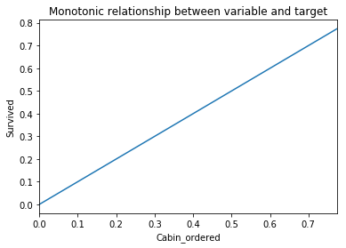

```python
# plot the transformed result: the monotonic variable

fig = plt.figure()
fig = X_train.groupby(['Cabin_ordered'])['Survived'].mean().plot()
fig.set_title('Monotonic relationship between variable and target')
fig.set_ylabel('Survived')
```

# 7. Probability Ratio Encoding

### Replace labels by joint probability of the target being 1 or 0

For each label, we calculate the mean of target=1, that is the probability of being 1 ( P(1) ), and also the probability of the target=0 ( P(0) ). And then, we calculate the ratio P(1)/P(0), and replace the labels by that ratio.

```python
# let's load again the titanic dataset

data = pd.read_csv('titanic_feature.csv', usecols=['Cabin', 'Survived'])
print(data.head())
print("\n")

# let's first fill NA values with an additional label

data.Cabin.fillna('Missing', inplace=True)
print(data.head())
print("\n")

print(len(data.Cabin.unique())) # check number of different labels in Cabin

# Now we extract the first letter of the cabin
print("\n")
data['Cabin'] = data['Cabin'].astype(str).str[0]
print(data.head())
print("\n")
# check the labels
print(data.Cabin.unique())
```

```
   Survived Cabin
0         0   NaN
1         1   C85
2         1   NaN
3         1  C123
4         0   NaN


   Survived    Cabin
0         0  Missing
1         1      C85
2         1  Missing
3         1     C123
4         0  Missing


148


   Survived Cabin
0         0     M
1         1     C
2         1     M
3         1     C
4         0     M


['M' 'C' 'E' 'G' 'D' 'A' 'B' 'F' 'T']
```

```python
# Let's separate into training and testing set

X_train, X_test, y_train, y_test = train_test_split(data[['Cabin', 'Survived']], data.Survived, test_size=0.3,
                                                    random_state=0)
X_train.shape, X_test.shape

# let's calculate the probability of Survived (target=1)
X_train.groupby(['Cabin'])['Survived'].mean()
```

```
Cabin
A    0.428571
B    0.774194
C    0.571429
D    0.692308
E    0.740741
F    0.666667
G    0.500000
M    0.303609
T    0.000000
Name: Survived, dtype: float64
```

```python
# let's make a dataframe with the above

prob_df = X_train.groupby(['Cabin'])['Survived'].mean()
prob_df = pd.DataFrame(prob_df)
prob_df
```

| Cabin | Survived |
| --- | --- |
| A | 0.428571 |
| B | 0.774194 |
| C | 0.571429 |
| D | 0.692308 |
| E | 0.740741 |
| F | 0.666667 |
| G | 0.500000 |
| M | 0.303609 |
| T | 0.000000 |

```python
# now let's  calculate the probability of target = 0 (people who did not survive)
prob_df = X_train.groupby(['Cabin'])['Survived'].mean()
prob_df = pd.DataFrame(prob_df)
prob_df['Died'] = 1-prob_df.Survived
prob_df
```

| Cabin | Survived | Died |
| --- | --- | --- |
| A | 0.428571 | 0.571429 |
| B | 0.774194 | 0.225806 |
| C | 0.571429 | 0.428571 |
| D | 0.692308 | 0.307692 |
| E | 0.740741 | 0.259259 |
| F | 0.666667 | 0.333333 |
| G | 0.500000 | 0.500000 |
| M | 0.303609 | 0.696391 |
| T | 0.000000 | 1.000000 |

```python
#  and now the ratio

prob_df['ratio'] = prob_df.Survived/prob_df.Died
prob_df
```

| Cabin | Survived | Died | ratio |
| --- | --- | --- | --- |
| A | 0.428571 | 0.571429 | 0.750000 |
| B | 0.774194 | 0.225806 | 3.428571 |
| C | 0.571429 | 0.428571 | 1.333333 |
| D | 0.692308 | 0.307692 | 2.250000 |
| E | 0.740741 | 0.259259 | 2.857143 |
| F | 0.666667 | 0.333333 | 2.000000 |
| G | 0.500000 | 0.500000 | 1.000000 |
| M | 0.303609 | 0.696391 | 0.435976 |
| T | 0.000000 | 1.000000 | 0.000000 |

```python
# let's make a dictionary with the above ratio

prob_df['ratio'].to_dict()
```

```
{'A': 0.75,
 'B': 3.428571428571428,
 'C': 1.3333333333333333,
 'D': 2.25,
 'E': 2.8571428571428563,
 'F': 1.9999999999999998,
 'G': 1.0,
 'M': 0.4359756097560975,
 'T': 0.0}
```

```python
ordered_labels = prob_df['ratio'].to_dict()
print(ordered_labels)
```

```
{'A': 0.75, 'B': 3.428571428571428, 'C': 1.3333333333333333, 'D': 2.25, 'E': 2.8571428571428563, 'F': 1.9999999999999998, 'G': 1.0, 'M': 0.4359756097560975, 'T': 0.0}
```

```python
# replace the labels with the ratios

X_train['Cabin_ordered'] = X_train.Cabin.map(ordered_labels)
X_test['Cabin_ordered'] = X_test.Cabin.map(ordered_labels)
```

```python
# check the results

X_train.head()
```

|  | Cabin | Survived | Cabin_ordered |
| --- | --- | --- | --- |
| 857 | E | 1 | 2.857143 |
| 52 | D | 1 | 2.250000 |
| 386 | M | 0 | 0.435976 |
| 124 | D | 0 | 2.250000 |
| 578 | M | 0 | 0.435976 |

```python
# plot the original variable

fig = plt.figure()
fig = X_train.groupby(['Cabin'])['Survived'].mean().plot()
fig.set_title('Normal relationship between variable and target')
fig.set_ylabel('Survived')
```

```
Text(0,0.5,'Survived')
```

```
Text(0,0.5,'Survived')
```

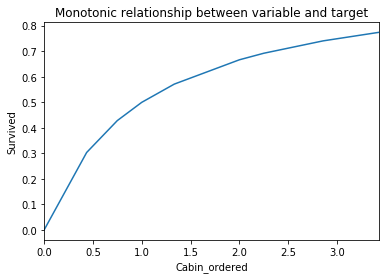

```python
# plot the transformed result: the monotonic variable

fig = plt.figure()
fig = X_train.groupby(['Cabin_ordered'])['Survived'].mean().plot()
fig.set_title('Monotonic relationship between variable and target')
fig.set_ylabel('Survived')
```

As you can see in the above plot, there is now a monotonic relationship between the variable Cabin and probability of survival. The higher the Cabin number, the more likely the person was to survive.

### Note

Monotonic does not mean strictly linear. Monotonic means that it increases constantly, or it decreases constantly.

# 8. Weight of Evidence

Weight of Evidence (WoE) was developed primarily for the credit and financial industries to help build more predictive models to evaluate the risk of loan default. That is, to predict how likely the money lent to a person or institution is to be lost. Thus, Weight of Evidence is a measure of the "strength” of a grouping technique to separate good and bad risk (default).

It is computed from the basic odds ratio:

## ln( (Proportion of Good Credit Outcomes) / (Proportion of Bad Credit Outcomes))

## 1: WoE will be 0 if the P(Goods) / P(Bads) = 1. That is, if the outcome is random for that group.

## 2: If P(Bads) > P(Goods) the odds ratio will be < 1 and the WoE will be < 0;

## 3: If, on the other hand, P(Goods) > P(Bads) in a group, then WoE > 0.

WoE is well suited for Logistic Regression, because the Logit transformation is simply the log of the odds, i.e., ln(P(Goods)/P(Bads)). Therefore, by using WoE-coded predictors in logistic regression, the predictors are all prepared and coded to the same scale, and the parameters in the linear logistic regression equation can be directly compared.

The WoE transformation has three advantages:

- It establishes a monotonic relationship to the dependent variable.
- It orders the categories on a "logistic" scale which is natural for logistic regression
- The transformed variables, can then be compared because they are on the same scale. Therefore, it is possible to determine which one is more predictive.

The WoE also has three drawbacks:

- May incur in loss of information (variation) due to binning to few categories (we will discuss this further in the discretisation section)
- It does not take into account correlation between independent variables
- Prone to cause over-fitting

For more details follow this link:

http://documentation.statsoft.com/StatisticaHelp.aspx?path=WeightofEvidence/WeightofEvidenceWoEIntroductoryOverview

```python
# let's load again the titanic dataset

data = pd.read_csv('titanic_feature.csv', usecols=['Cabin', 'Survived'])
print(data.head())
print("\n")

# let's first fill NA values with an additional label

data.Cabin.fillna('Missing', inplace=True)
print(data.head())
print("\n")

print(len(data.Cabin.unique())) # check number of different labels in Cabin

# Now we extract the first letter of the cabin
print("\n")
data['Cabin'] = data['Cabin'].astype(str).str[0]
print(data.head())
print("\n")
# check the labels
print(data.Cabin.unique())
```

```
   Survived Cabin
0         0   NaN
1         1   C85
2         1   NaN
3         1  C123
4         0   NaN


   Survived    Cabin
0         0  Missing
1         1      C85
2         1  Missing
3         1     C123
4         0  Missing


148


   Survived Cabin
0         0     M
1         1     C
2         1     M
3         1     C
4         0     M


['M' 'C' 'E' 'G' 'D' 'A' 'B' 'F' 'T']
```

```python
# Let's divide into train and test set

X_train, X_test, y_train, y_test = train_test_split(data[['Cabin', 'Survived']], data.Survived, test_size=0.3,
                                                    random_state=0)
X_train.shape, X_test.shape

# now we calculate the probability of target=1
X_train.groupby(['Cabin'])['Survived'].mean()

# let's make a dataframe with the above calculation

prob_df = X_train.groupby(['Cabin'])['Survived'].mean()
prob_df = pd.DataFrame(prob_df)
prob_df

# and now the probability of target = 0
# and we add it to the dataframe

prob_df = X_train.groupby(['Cabin'])['Survived'].mean()
prob_df = pd.DataFrame(prob_df)
prob_df['Died'] = 1-prob_df.Survived
prob_df
```

| Cabin | Survived | Died |
| --- | --- | --- |
| A | 0.428571 | 0.571429 |
| B | 0.774194 | 0.225806 |
| C | 0.571429 | 0.428571 |
| D | 0.692308 | 0.307692 |
| E | 0.740741 | 0.259259 |
| F | 0.666667 | 0.333333 |
| G | 0.500000 | 0.500000 |
| M | 0.303609 | 0.696391 |
| T | 0.000000 | 1.000000 |

```python
# since the log of zero is not defined, let's set this number to something small and non-zero

prob_df.loc[prob_df.Survived == 0, 'Survived'] = 0.001
prob_df
```

| Cabin | Survived | Died |
| --- | --- | --- |
| A | 0.428571 | 0.571429 |
| B | 0.774194 | 0.225806 |
| C | 0.571429 | 0.428571 |
| D | 0.692308 | 0.307692 |
| E | 0.740741 | 0.259259 |
| F | 0.666667 | 0.333333 |
| G | 0.500000 | 0.500000 |
| M | 0.303609 | 0.696391 |
| T | 0.001000 | 1.000000 |

```python
# now we calculate the WoE

prob_df['WoE'] = np.log(prob_df.Survived/prob_df.Died)
prob_df
```

| Cabin | Survived | Died | WoE |
| --- | --- | --- | --- |
| A | 0.428571 | 0.571429 | -0.287682 |
| B | 0.774194 | 0.225806 | 1.232144 |
| C | 0.571429 | 0.428571 | 0.287682 |
| D | 0.692308 | 0.307692 | 0.810930 |
| E | 0.740741 | 0.259259 | 1.049822 |
| F | 0.666667 | 0.333333 | 0.693147 |
| G | 0.500000 | 0.500000 | 0.000000 |
| M | 0.303609 | 0.696391 | -0.830169 |
| T | 0.001000 | 1.000000 | -6.907755 |

```python
# and we create a dictionary to re-map the variable

prob_df['WoE'].to_dict()
```

```
{'A': -0.2876820724517809,
 'B': 1.232143681292632,
 'C': 0.28768207245178085,
 'D': 0.8109302162163288,
 'E': 1.0498221244986774,
 'F': 0.6931471805599452,
 'G': 0.0,
 'M': -0.8301689781242366,
 'T': -6.907755278982137}
```

```python
# and we make a dictionary to map the orignal variable to the WoE
# same as above but we capture the dictionary in a variable

ordered_labels = prob_df['WoE'].to_dict()
```

```python
# replace the labels with the WoE

X_train['Cabin_ordered'] = X_train.Cabin.map(ordered_labels)
X_test['Cabin_ordered'] = X_test.Cabin.map(ordered_labels)
```

```python
# check the results

X_train.head()
```

|  | Cabin | Survived | Cabin_ordered |
| --- | --- | --- | --- |
| 857 | E | 1 | 1.049822 |
| 52 | D | 1 | 0.810930 |
| 386 | M | 0 | -0.830169 |
| 124 | D | 0 | 0.810930 |
| 578 | M | 0 | -0.830169 |

```
Text(0,0.5,'Survived')
```

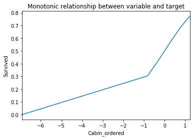

```python
# plot the original variable

fig = plt.figure()
fig = X_train.groupby(['Cabin'])['Survived'].mean().plot()
fig.set_title('Normal relationship between variable and target')
fig.set_ylabel('Survived')

# plot the transformed result: the monotonic variable

fig = plt.figure()
fig = X_train.groupby(['Cabin_ordered'])['Survived'].mean().plot()
fig.set_title('Monotonic relationship between variable and target')
fig.set_ylabel('Survived')
```

In the above plot, there is now a monotonic relationship between the variable Cabin and probability of survival. The higher the Cabin number, the more likely the person was to survive.

### Note

Monotonic does not mean strictly linear. Monotonic means that it increases constantly, or it decreases constantly.